# Assignment4

Donovan Kott

2023-10-06

```r
data2 <- read.csv("C:/Users/dmkot/Downloads/Unemployment in America Per US State.csv")
str(data2)
```

```
## 'data.frame':    29892 obs. of  11 variables:
##  $ FIPS.Code                                                : int  1 2 4 5 6 37 8 9 10 11 ...
##  $ State.Area                                               : chr  "Alabama" "Alaska" "Arizona" "Arkansas" ...
##  $ Year                                                     : int  1976 1976 1976 1976 1976 1976 1976 1976 1976 1976 ...
##  $ Month                                                    : int  1 1 1 1 1 1 1 1 1 1 ...
##  $ Total.Civilian.Non.Institutional.Population.in.State.Area: chr  "2,605,000   " "232,000   " "1,621,000   " "1,536,000   " ...
##  $ Total.Civilian.Labor.Force.in.State.Area                 : chr  "1,484,555   " "160,183   " "964,120   " "889,044   " ...
##  $ Percent.....of.State.Area.s.Population                   : num  57 69 59.5 57.9 62.6 64.1 67.2 64.2 62.7 64.4 ...
##  $ Total.Employment.in.State.Area                           : chr  "1,386,023   " "148,820   " "865,871   " "824,395   " ...
##  $ Percent.....of.Labor.Force.Employed.in.State.Area        : num  53.2 64.1 53.4 53.7 56.8 58.4 63.3 57.9 57.7 58.8 ...
##  $ Total.Unemployment.in.State.Area                         : chr  "98,532   " "11,363   " "98,249   " "64,649   " ...
##  $ Percent.....of.Labor.Force.Unemployed.in.State.Area      : num  6.6 7.1 10.2 7.3 9.2 8.9 5.8 9.8 8 8.7 ...
```

```r
data3 = data2[data2$State.Area == "New Jersey",]
head(data3)
```

```
##     FIPS.Code State.Area Year Month
## 32         34 New Jersey 1976     1
## 85         34 New Jersey 1976     2
## 138        34 New Jersey 1976     3
## 191        34 New Jersey 1976     4
## 244        34 New Jersey 1976     5
## 297        34 New Jersey 1976     6
##     Total.Civilian.Non.Institutional.Population.in.State.Area
## 32                                               5,358,000
## 85                                               5,363,000
## 138                                              5,367,000
## 191                                              5,372,000
## 244                                              5,376,000
## 297                                              5,381,000
##     Total.Civilian.Labor.Force.in.State.Area
```

[output cut: 34 more lines]

```r
library(fpp)
library(fpp2)
library(TTR)
```

Interesting to see that the unemployment rate has gone up and down in various cycles throughout the years and really spiked during the pandemic

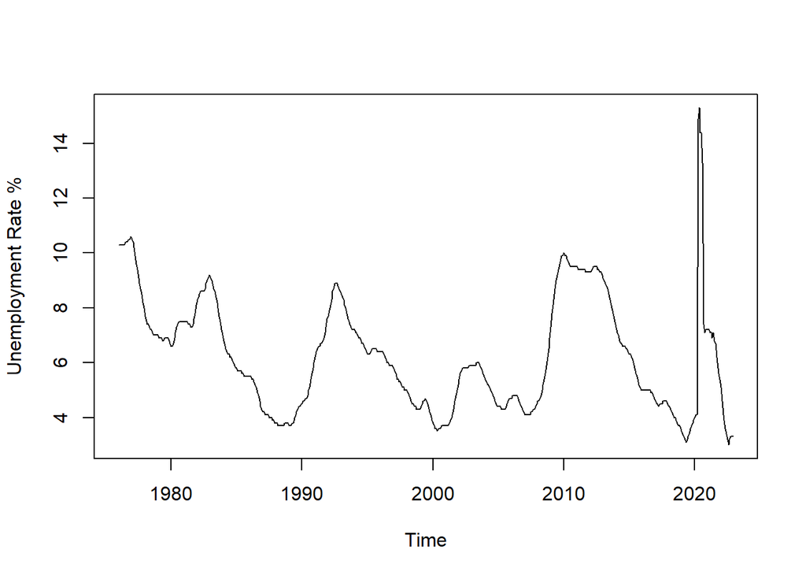

```r
myts = ts(data3$Percent.....of.Labor.Force.Unemployed.in.State.Area, start=c(1976,1), end=c(2022,12), frequency=12)
plot(myts, ylab="Unemployment Rate %")
```

```r
attributes(myts)
```

```
## $tsp
## [1] 1976.000 2022.917   12.000
##
## $class
## [1] "ts"
```

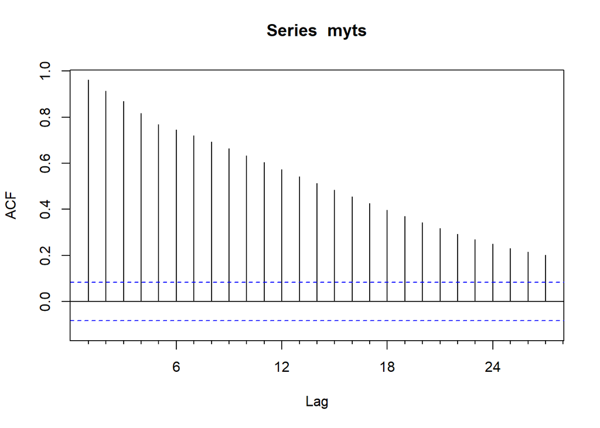

```r
Acf(myts)
```

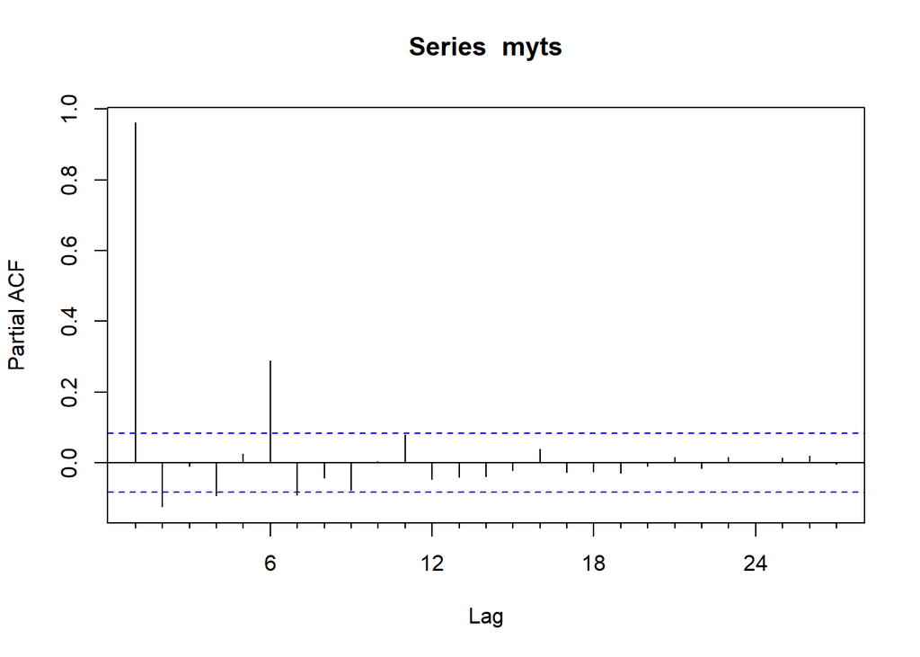

```r
Pacf(myts)
```

Take Mean of all available history: We can see the mean is a little above 6%. While this is useful information it does not make the best predictor because it doesnt capture seasonality and trend. The RMSE is 2.07 which is pretty high.

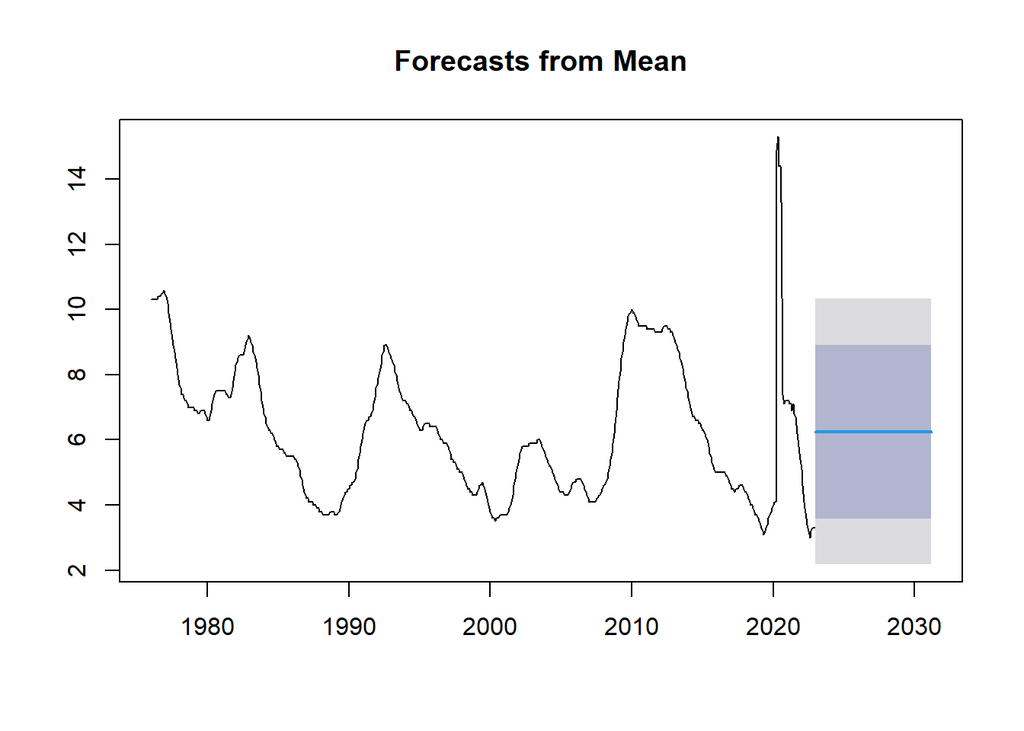

```r
mean_forecast = meanf(myts,99)
plot(mean_forecast)
```

```r
accuracy(mean_forecast)
```

```
##                        ME     RMSE      MAE       MPE     MAPE     MASE
## Training set 2.206144e-16 2.072356 1.696088 -10.87315 29.66838 1.531807
##                   ACF1
## Training set 0.9612126
```

Naive: We can see the forecast uses the last available data point at under 5% and uses that as its predictor. Once again not the best method for this kind of data as it doesn’t account for seasonality or trend. The RMSE is .5377 which is alot better than the previous forecast meaning the forecast is closer to the actual data

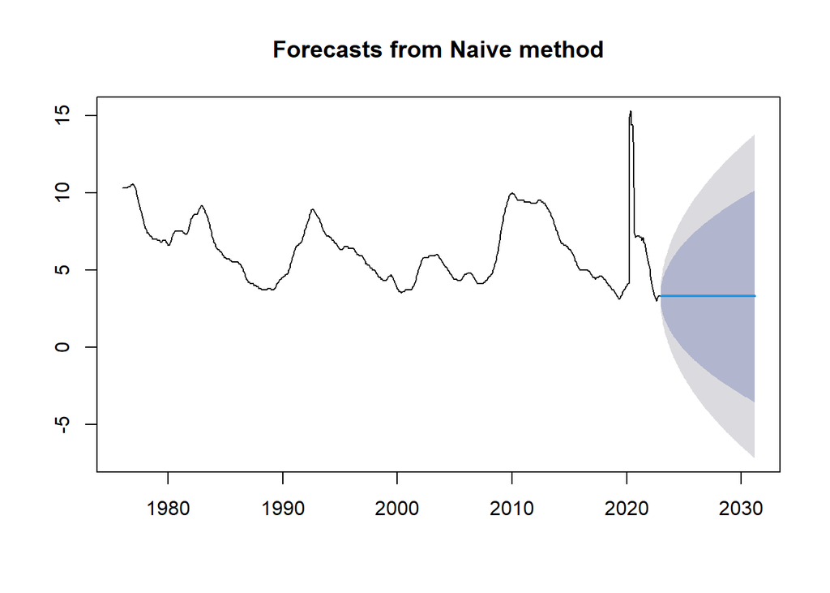

```r
naive_forecast = naive(myts,99)
plot(naive_forecast)
```

```r
accuracy(naive_forecast)
```

```
##                       ME      RMSE       MAE        MPE    MAPE      MASE
## Training set -0.01243339 0.5377408 0.1232682 -0.3657571 1.83853 0.1113286
##                   ACF1
## Training set 0.1167259
```

Random Walk: Shows the forecast going down over time because drift = true. When drift is false the forecast is more flat and constant. RMSE is .5375 which is slightly lower than Naive hence a better forecast.

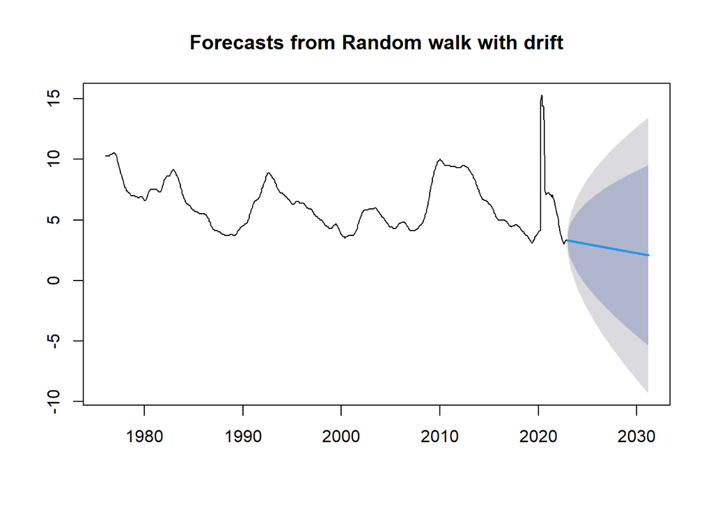

```r
rwf_forecast <- rwf(myts,99, drift=TRUE)
plot(rwf_forecast)
```

```r
accuracy(rwf_forecast)
```

```
##                        ME      RMSE       MAE       MPE     MAPE      MASE
## Training set 1.940526e-16 0.5375971 0.1256754 -0.145084 1.883311 0.1135026
##                   ACF1
## Training set 0.1167259
```

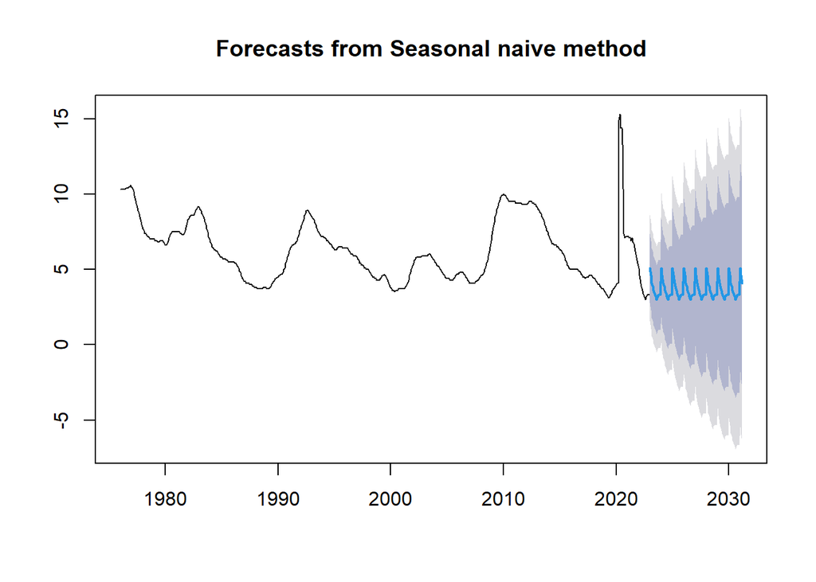

```r
snaive_forecast <- snaive(myts,99)
plot(snaive_forecast)
```

```r
accuracy(snaive_forecast)
```

```
##                      ME     RMSE      MAE       MPE     MAPE MASE      ACF1
## Training set -0.1460145 1.794961 1.107246 -5.474461 17.83802    1 0.9079284
```

Moving Averages: The Moving Average 5 forecast shows a slight upward incline. The RMSE is .1698 which is the lowest and best average so far.

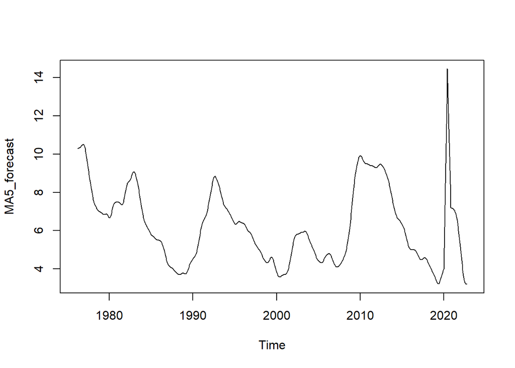

```r
MA5_forecast <- ma(myts,order=5)
plot(MA5_forecast)
```

```r
x3=forecast(MA5_forecast)
```

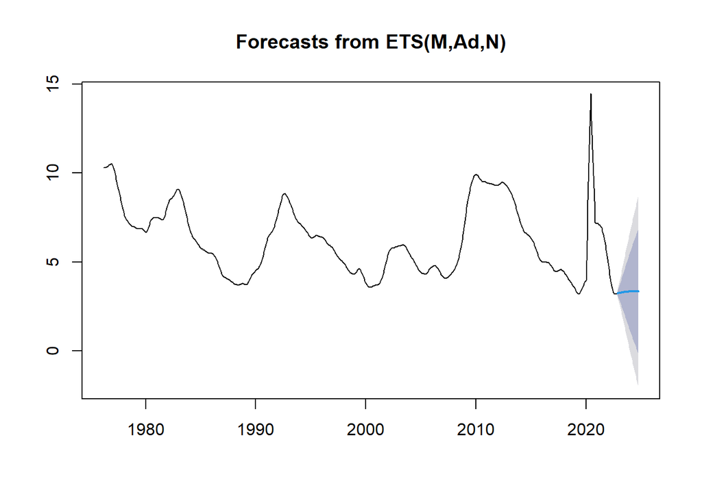

```r
plot(x3)
```

```r
accuracy(x3)
```

```
##                        ME      RMSE       MAE        MPE     MAPE       MASE
## Training set -0.001879811 0.1698215 0.0341635 0.04170265 0.510802 0.03174228
##                   ACF1
## Training set 0.1231252
```

Moving Averages Forecast 9: The MA 9 forecast is even better because it takes a longer moving window of data and in this case more accurate. The RMSE is .082 which is the lowest by far and the best prediction model so far.

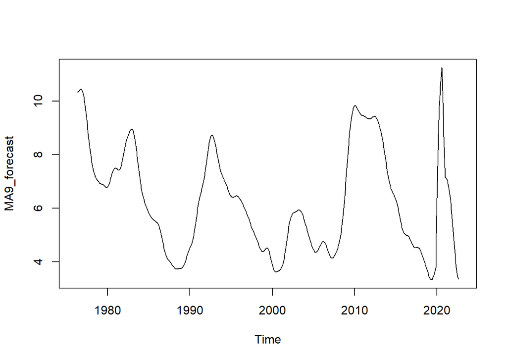

```r
MA9_forecast <- ma(myts,order=9)
plot(MA9_forecast)
```

```r
x4=forecast(MA9_forecast)
```

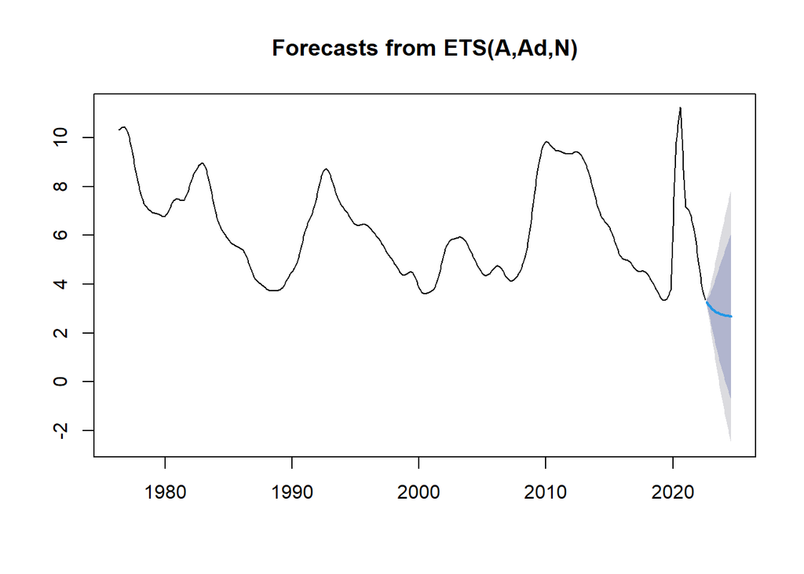

```r
plot(x4)
```

```r
accuracy(x4)
```

```
##                        ME       RMSE        MAE        MPE      MAPE       MASE
## Training set -0.001571766 0.08201902 0.02192648 0.02334366 0.3513956 0.02118442
##                   ACF1
## Training set 0.1368643
```

Moving Averages Forecast 27: The MA 27 forecast is even better because there were 27 significant lag spikes in the Acf plot. The RMSE is .0289 which is the lowest by far and the best prediction model so far.

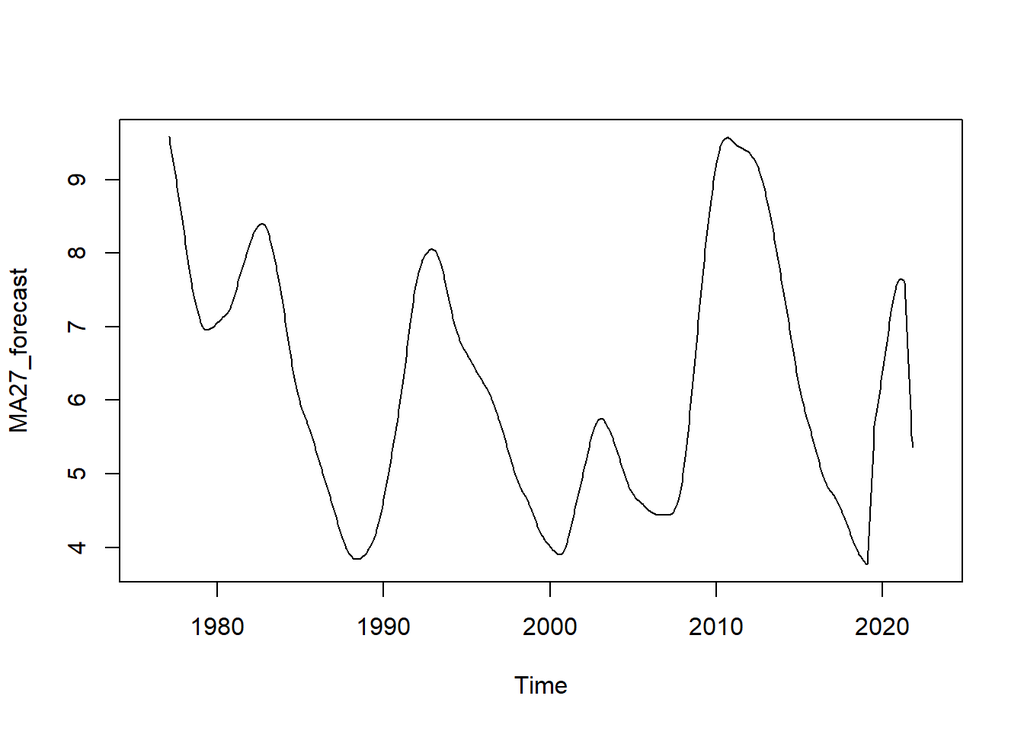

```r
MA27_forecast <- ma(myts,order=27)
plot(MA27_forecast)
```

```r
x5=forecast(MA27_forecast)
```

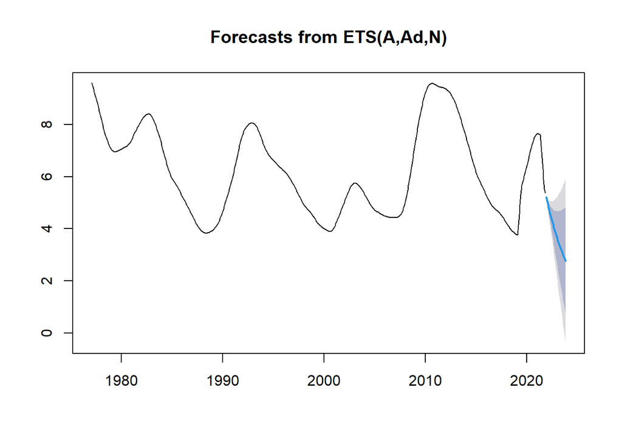

```r
plot(x5)
```

```r
accuracy(x5)
```

```
##                         ME       RMSE         MAE        MPE      MAPE
## Training set -0.0001263684 0.02885622 0.007976067 0.01774101 0.1363861
##                    MASE      ACF1
## Training set 0.01032665 0.1353439
```

Plot all in a single chart: You can see how accurate all the models are compared to the actual time series data. You can also compare how different the forecast predictions are. Interesting to see the how all the models weren’t that accurate around 2020 because the pandemic spiked the unemployment rate so high and really threw off the trend.

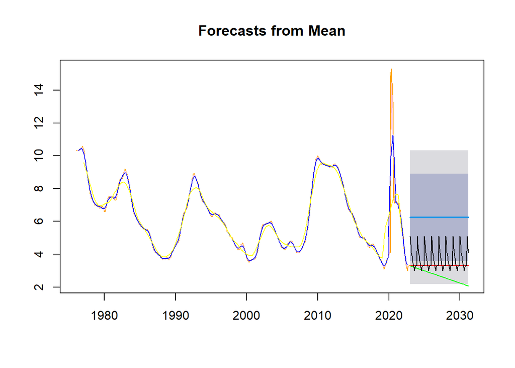

```r
plot(mean_forecast)
lines(myts, col="orange")
lines(naive_forecast$mean,col="red")
lines(rwf_forecast$mean,col="green")
lines(snaive_forecast$mean,col="black")
lines(MA5_forecast,col="Pink")
lines(MA9_forecast,col="Blue")
lines(MA27_forecast, col="yellow")
```

Decomposition: The exponential smoothing model has a RMSE of .5372 which is better than Naive and random walk but not MA9.

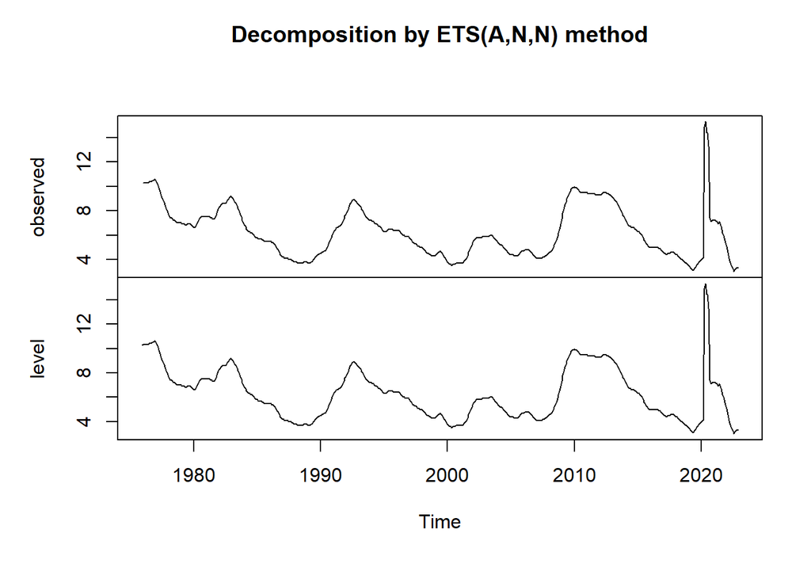

```r
ets_forecast <- ets(myts)
plot(ets_forecast)
```

```r
attributes(ets_forecast)
```

```
## $names
##  [1] "loglik"     "aic"        "bic"        "aicc"       "mse"
##  [6] "amse"       "fit"        "residuals"  "fitted"     "states"
## [11] "par"        "m"          "method"     "series"     "components"
## [16] "call"       "initstate"  "sigma2"     "x"
##
## $class
## [1] "ets"
```

```r
accuracy(ets_forecast)
```

```
##                       ME      RMSE       MAE        MPE     MAPE      MASE
## Training set -0.01237738 0.5372708 0.1230965 -0.3648089 1.835787 0.1111735
##                   ACF1
## Training set 0.1168244
```

```r
ets_forecast$mse
```

```
## [1] 0.28866
```

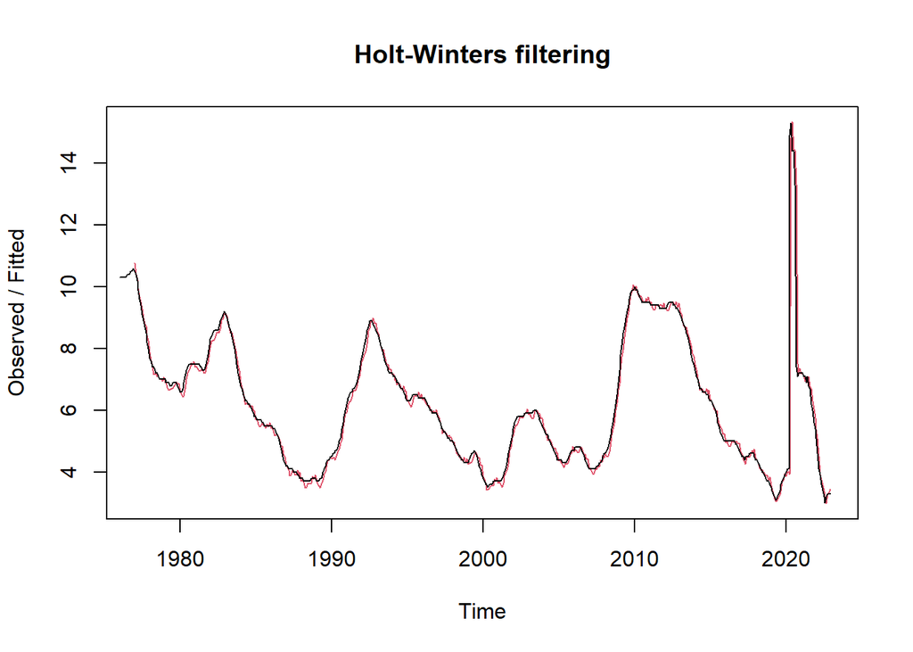

```r
HW_forecast <- HoltWinters(myts)
plot(HW_forecast)
```

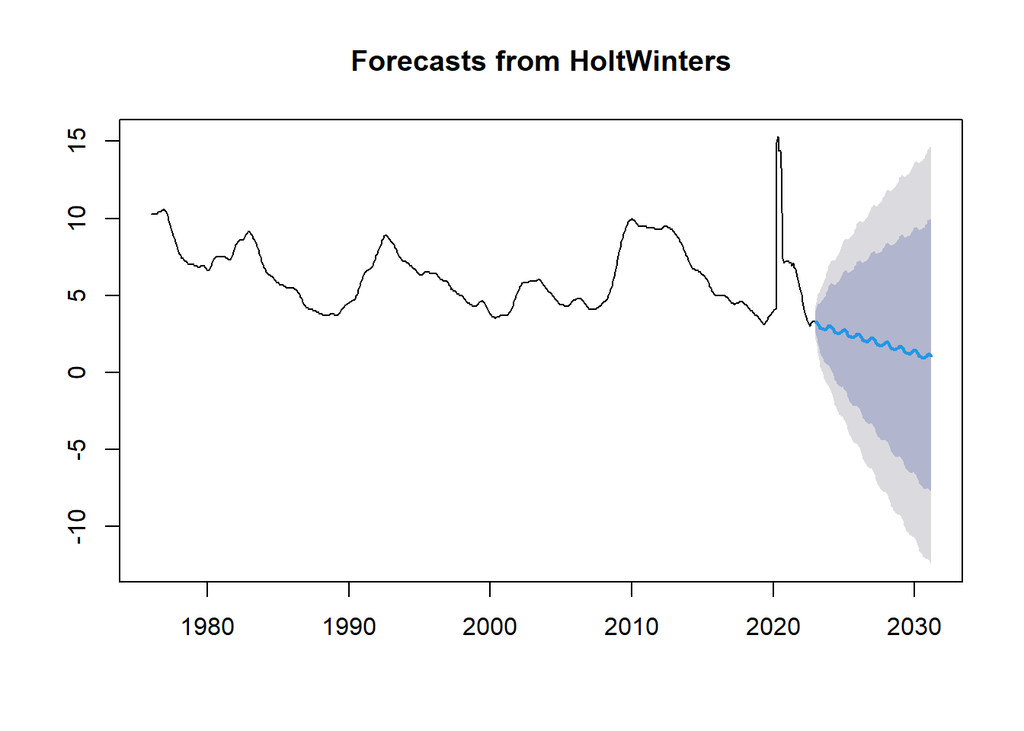

```r
x1=forecast(HW_forecast, h=99)
plot(x1)
```

```r
accuracy(x1)
```

```
##                      ME      RMSE       MAE       MPE     MAPE    MASE
## Training set 0.02523836 0.5565413 0.1551917 0.3112278 2.429799 0.14016
##                   ACF1
## Training set 0.1376152
```

HoltWinters no Beta or gamma: With beta as false it does exponential smoothing and with gamma as false it does a non seasonal model. The RMSE is .5377 which is extremely similar to the exponential smoothing forecast model.

```r
SSE_Simple <- HoltWinters(myts,beta=FALSE,gamma=FALSE)
attributes(SSE_Simple)
```

```
## $names
## [1] "fitted"       "x"            "alpha"        "beta"         "gamma"
## [6] "coefficients" "seasonal"     "SSE"          "call"
##
## $class
## [1] "HoltWinters"
```

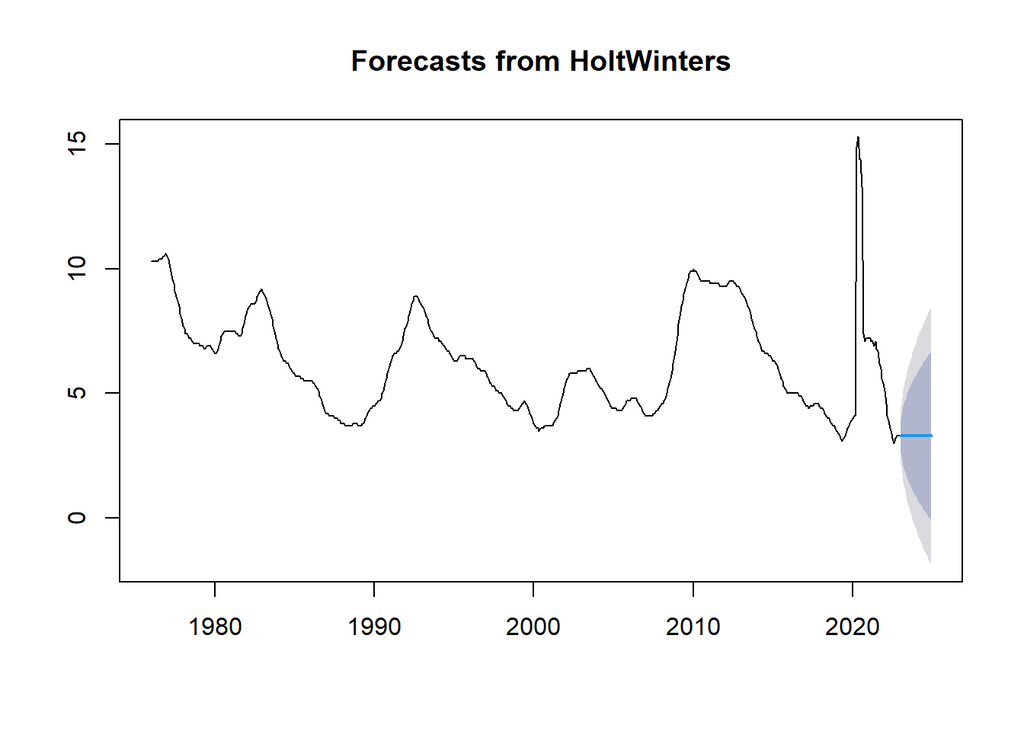

```r
x2=forecast(SSE_Simple)
plot(x2)
```

```r
accuracy(x2)
```

```
##                       ME      RMSE       MAE        MPE     MAPE      MASE
## Training set -0.01243399 0.5377439 0.1232738 -0.3657776 1.838615 0.1113337
##                   ACF1
## Training set 0.1167727
```

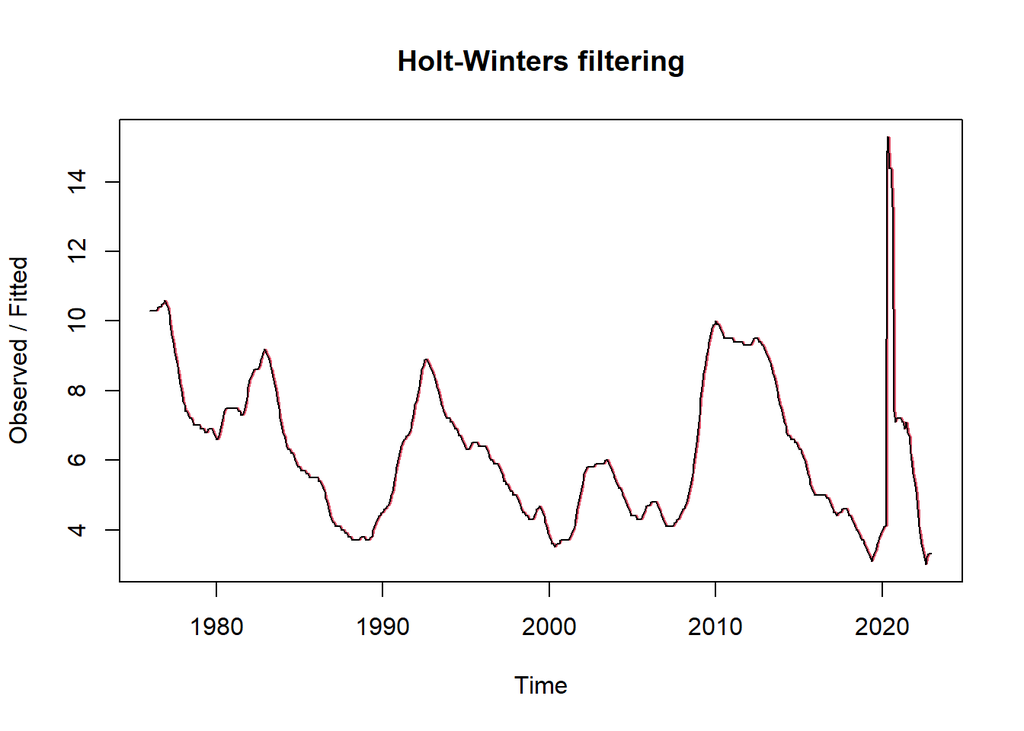

```r
plot(SSE_Simple)
```

```r
SSE_Simple$SSE
```

```
## [1] 162.8018
```

```r
head(SSE_Simple$fitted)
```

```
##          xhat level
## Feb 1976 10.3  10.3
## Mar 1976 10.3  10.3
## Apr 1976 10.3  10.3
## May 1976 10.3  10.3
## Jun 1976 10.3  10.3
## Jul 1976 10.3  10.3
```

The best model for my unemployment data set is the Moving Average model and more specifically the MA27 model because there were 27 significant lag spikes in the Acf plot. MA27 has the lowest RMSE of .0289 out of all the models and therefore makes the best predictor in this case.